# Demo

Jiayi Wang

Institute for Molecular Life Sciences, University of Zurich, SwitzerlandSIB Swiss Institute of Bioinformatics, University of Zurich, Switzerland

Helena L Crowell

Institute for Molecular Life Sciences, University of Zurich, SwitzerlandSIB Swiss Institute of Bioinformatics, University of Zurich, Switzerland

Mark D Robinson

Institute for Molecular Life Sciences, University of Zurich, SwitzerlandSIB Swiss Institute of Bioinformatics, University of Zurich, Switzerland

July 01, 2025

# preamble

## dependencies

```r
library(scran)
library(scater)
library(igraph)
library(UpSetR)
library(ggplot2)
library(patchwork)
```

## simulation

```r
# simulation
wcs <- list(t=80, s=80, b=0)
sim_rds <- tempfile(fileext=".rds")
args <- list(res=sim_rds)
source("code/00-get_sim.R")
(sim <- readRDS(args$res))
```

```
## class: SingleCellExperiment
## dim: 2000 2412
## metadata(3): t s b
## assays(6): BatchCellMeans BaseCellMeans ... TrueCounts counts
## rownames(2000): gene0001 gene0002 ... gene1999 gene2000
## rowData names(59): sample_1.Group1.Gene._ sample_1.Group1.GeneMean._
##   ... cvQuantileNorm gene_id
## colnames(2412): cell0001 cell0002 ... cell2411 cell2412
## colData names(4): cluster_id sample_id group_id cell_id
## reducedDimNames(0):
## mainExpName: NULL
## altExpNames(0):
```

## processing

Next, we perform minimal filtering (excluding low-quality genes and cells) and preprocessing steps (normalization, principal component analysis), as well as low- and high-resolution graph-based clustering. The resulting `cluster_lo/hi` (stored as `colData`) assignments, and biological variance component estimates (`rowData` slot `bio`) are used by different feature scores/selections below.

[figure not shown]

```r
# keep genes with count > 1 in at least 10 cells,
# and cells with at least 10 detected genes
y <- counts(sim)
gs <- rowSums(y > 1) >= 10
cs <- colSums(y > 0) >= 10
sim <- sim[gs, cs]

# log-library size normalization,
# feature selection, dimension reduction
sim <- logNormCounts(sim)
tbl <- modelGeneVar(sim, block=sim$sample_id)
hvg <- (rowData(sim)$bio <- tbl$bio ) > 0
sim <- runPCA(sim, subset_row=hvg, ncomponents=10)

# high- & low-resolution clustering
g <- buildSNNGraph(sim, use.dimred="PCA")
lo <- cluster_louvain(g, resolution=0)
hi <- cluster_louvain(g, resolution=2)
sim$cluster_lo <- factor(lo$membership)
sim$cluster_hi <- factor(hi$membership)
```

# analysis

## scoring

We first source feature scoring scripts. Each defines a function that takes as input a `SingleCellExperiment`, and returns a score for each gene.

```r
# source scoring functions & assign to variables
sco <- list.files("code", "02-sco-", full.names=TRUE)
(ids <- gsub(".*-(.*)\\..*", "\\1", sco))
```

```
## [1] "HVG"    "PVE"    "random" "sPBDS"  "tF"
```

```r
names(sco) <- names(sco_ids) <- sco_ids <- ids
for (. in sco_ids) { source(sco[.]); assign(., fun) }
# view exemplary function definition
HVG
```

```
## function (x)
## setNames(rowData(x)$bio, rownames(x))
```

Looping through these, we can compute a set of gene scores; here, using all strategies. In reality, only one or two scores would be sufficient.

```r
# run scoring
sco_res <- lapply(sco_ids, \(.) get(.)(sim))
# consolidate into table
names(sco_res)[2] <- ""
sco_res <- data.frame(sco_res)
# view results for a few genes
head(sco_res)
```

```
##                  HVG         tPVE         sPVE    random       sPBDS        tF
## gene0001 -0.04701965 0.0026872371 1.239897e-08 0.5784488  0.53258327 0.8841193
## gene0002  0.02780804 0.0002151033 4.668944e-02 0.7513767 13.11529926 0.5103725
## gene0003 -0.07644198 0.0011087697 0.000000e+00 0.8596293  0.53918511 0.8514529
## gene0004  0.06772763 0.0235578830 1.682829e-02 0.0109303 12.25677260 1.0000000
## gene0005 -0.07225264 0.0000000000 7.779002e-13 0.1125348  0.01430276 0.3679616
## gene0006 -0.02079375 0.0000000000 0.000000e+00 0.8602876  0.07513587 0.5584136
```

## selection

Analogous to above, we next source feature selection scripts. Each of these functions relies the above scores to select 2,000 genes. Specifically, selections with a `_` are based on the rank difference of two scores; remaining selections rely on one score only.

```r
# source scoring functions & assign to variables
sel <- list.files("code", "03-sel_dat-", full.names=TRUE)
(ids <- gsub(".*-(.*)\\..*", "\\1", sel))
```

```
## [1] "HVG"       "random"    "tF_sPBDS"  "tF_sPVE"   "tF"        "tPVE_sPVE"
```

```r
names(sel) <- names(sel_ids) <- sel_ids <- ids
for (. in sel_ids) { source(sel[.]); assign(., fun) }
# view exemplary function definition
tF_sPBDS
```

```
## function (x)
## {
##     n <- 2000
##     t <- rank((y <- x$tF)$sco_val)
##     s <- rank(x$sPBDS$sco_val)
##     o <- order(t - s, decreasing = TRUE)
##     y$gene_id[o[seq_len(n)]]
## }
```

Again, we loop through all selection strategies to obtain a set of genes of each. These functions default to selecting the top-2,000 ranked genes, which might be reasonable in experimental data. However, because this is synthetic data and we only simulated 2,000 genes, we subset selections to the top-200 ranked genes.

```r
# selection scripts expects a list of
# - gene_id = feature identifiers
# - sco_val = score values
sco_ret <- lapply(
    asplit(sco_res, 2), \(.)
    list(gene_id=names(.), sco_val=.))
# run selections
sel_res <- lapply(sel_ids, \(.) get(.)(sco_ret)[seq_len(200)])
# view first couple features
sapply(sel_res, head)
```

```
##      HVG        random     tF_sPBDS   tF_sPVE    tF         tPVE_sPVE
## [1,] "gene1455" "gene1203" "gene0022" "gene0014" "gene0012" "gene1132"
## [2,] "gene1437" "gene0448" "gene1222" "gene0015" "gene0014" "gene0599"
## [3,] "gene1740" "gene0371" "gene0166" "gene0019" "gene0015" "gene1418"
## [4,] "gene1057" "gene1425" "gene0262" "gene0024" "gene0019" "gene0372"
## [5,] "gene0192" "gene0484" "gene0404" "gene0066" "gene0020" "gene0024"
## [6,] "gene0021" "gene1747" "gene1011" "gene0068" "gene0021" "gene1991"
```

## visuals

We here refrain from any quantitative evaluation and instead, briefly, qualitatively/visually compare different feature selection strategies.

### agreement

The arguably simplest comparison is to compute and visualize, for all sets of strategies, the number of features unique/common between them. E.g., we can observe that *random* selection results in the least overlaps, and selections involvins *tF* and *sPVE*, respectively, share a few genes.

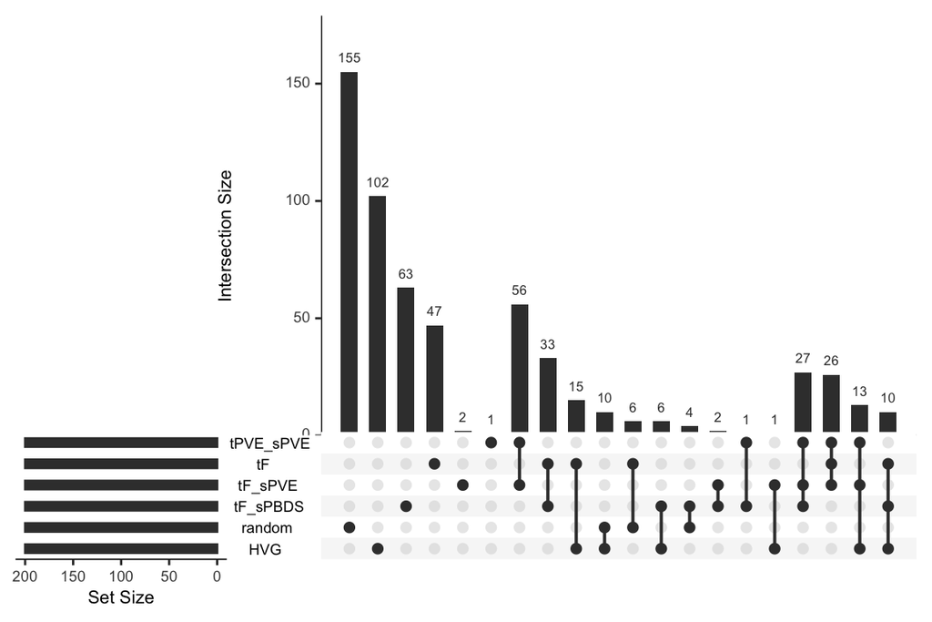

```r
# count how many genes are in common
# between different selection strategies
upset(fromList(sel_res), sets=sel_ids, nintersects=20)
```

### reduction

Lastly, we can use feature subsets for principal component analysis (PCA) that, in practice, may underlie downstream analyses such as integration and clustering. We also visually compare the top-2 PCs colored by group/experiment condition and cluster/cell type, respectively. Ideally, we would like to observe that clusters are well separated but not groups. E.g., we can observe that HVGs lead do to some extend separate clusters but also groups, while type- and type-state- based selection result in a better separation of clusters and well-mixed groups.

```r
# do principal component analysis
# using different feature selections
sim_ <- lapply(sel_res, \(.) runPCA(sim, subset_row=.))
```

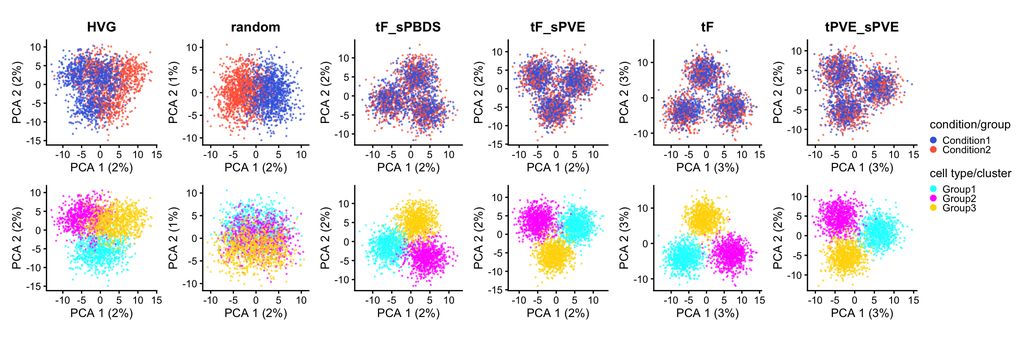

```r
# plotting
ps <- lapply(names(sim_), \(.) {
    p <- plotPCA(sim_[[.]],
        # coloring by condition/group
        point_size=0.2, colour_by="group_id") +
        scale_color_manual(
            "condition/group",
            values=c("royalblue", "tomato"))
    q <- plotPCA(sim_[[.]],
        # coloring by cell type/cluster
        point_size=0.2, colour_by="cluster_id") +
        scale_color_manual(
            "cell type/cluster",
            values=c("cyan", "magenta", "gold"))
    list(p+ggtitle(.), q)
}) |> Reduce(f=c)
# aesthetics
wrap_plots(ps) +
    plot_layout(nrow=2, byrow=FALSE, guides="collect") &
    guides(col=guide_legend(override.aes=list(alpha=1, size=2))) &
    coord_equal() & theme(
        legend.key.size=unit(0, "pt"),
        plot.title=element_text(hjust=0.5))
```